# GAM en series de tiempo: Prophet

Juan Manuel Barriola, Azul Villanueva y Franco Mastelli

05 de Noviembre de 2022

```r
library(dplyr)
library(ggplot2)
library(prophet)
library(lubridate)
library(cowplot)
```

## Problema

Queremos **predecir el número de visitantes de un local de ropa** en un determinado momento.

### Carga de datos

El dataset consiste en información real de 8 meses de visitantes de un local de ropa localizado en un shopping de gran tamaño.

```r
shopping <- read.csv('local-shopping_prophet.csv') %>%
  rename(.,visitantes=Total.de.Visitantes) %>%
  mutate(Dia = ymd(Dia))
glimpse(shopping)
```

```
Rows: 228
Columns: 3
$ Dia        <date> 2017-09-14, 2017-09-15, 2017-09-16, 2017-09-17, 2017-09-18, ~
$ visitantes <int> 589, 696, 1034, 940, 540, 526, 312, 553, 639, 793, 745, 8, 33~
$ Clima      <chr> "Parcialmente Nublado", "Soleado", "Soleado", "Parcialmente N~
```

Se observa que la serie de tiempo presenta un comportamiento cíclico con algunos eventos atípicos:

- Aumentos debidos a promociones y Navidad
- Caídas por cierre del local o caídas del sistema de medición

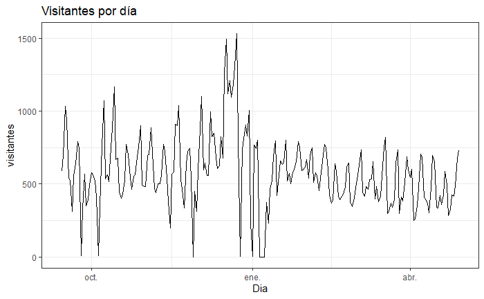

```r
ggplot(shopping, aes(Dia, visitantes)) + geom_line() + theme_bw() + labs(title='Visitantes por día')
```

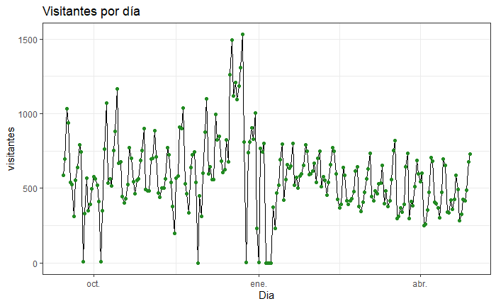

```r
ggplot(shopping, aes(Dia, visitantes)) + geom_line() + geom_point(color='forestgreen') + theme_bw() + labs(title='Visitantes por día')
```

# Técnicas de suavizado

Una primera aproximación puede ser tratar de utilizar técnicas de suavizado.

En este caso estamos utilizando **loess** como una herramienta gráfica con el comando `geom_smooth()` de ggplot.

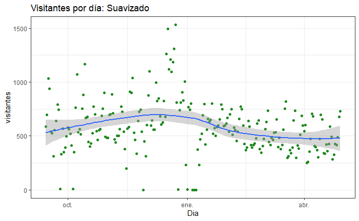

```r
ggplot(shopping, aes(Dia, visitantes)) + geom_point(color='forestgreen') + geom_smooth() + theme_bw() + labs(title='Visitantes por día: Suavizado')
```

Si bien está suavizando, el resultado es bastante pobre ya que el modelo no está logrando representar bien la variabilidad de los datos.

## Distintas ventanas

Ahora realizamos 4 modelos de LOESS modificando la ventana (**span**) para cada uno de ellos.

Especificamos:

*formula*: fórmula que especifica la respuesta numérica y el predictor numérico.

*na.acción*: la acción que se realizará con valores NA en la respuesta o predictores.

*model*: ¿Debería devolverse el dataframe del modelo? (T/F)

*span*: el parámetro α que controla el grado de suavizado.

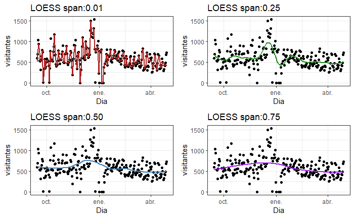

```r
loess=stats::loess(visitantes~as.numeric(Dia), data = shopping, na.action = 'na.exclude', model = T, span=0.01)
shopping['loess']=predict(loess,shopping)
loess_1 = ggplot(shopping, aes(Dia,visitantes)) + geom_point() + geom_line(aes(y=loess), color='firebrick', size=1) +
  labs(title= "LOESS span:0.01") + theme_bw()

loess=stats::loess(visitantes~as.numeric(Dia), data = shopping, na.action = 'na.exclude', model = T, span=0.25)
shopping['loess']=predict(loess,shopping)
loess_2 = ggplot(shopping, aes(Dia,visitantes)) + geom_point() + geom_line(aes(y=loess), color='forestgreen', size=1) +
  labs(title= "LOESS span:0.25") + theme_bw()

loess=stats::loess(visitantes~as.numeric(Dia), data = shopping, na.action = 'na.exclude', model = T, span=0.5)
shopping['loess']=predict(loess,shopping)
loess_3 = ggplot(shopping, aes(Dia,visitantes)) + geom_point() + geom_line(aes(y=loess), color='steelblue', size=1) +
  labs(title= "LOESS span:0.50") + theme_bw()

loess=stats::loess(visitantes~as.numeric(Dia), data = shopping, na.action = 'na.exclude', model = T, span=0.75)
shopping['loess']=predict(loess,shopping)
loess_4 = ggplot(shopping, aes(Dia,visitantes)) + geom_point() + geom_line(aes(y=loess), color='purple', size=1) +
  labs(title= "LOESS span:0.75") + theme_bw()

cowplot::plot_grid(loess_1, loess_2, loess_3,loess_4)
```

Se nota que para un **span muy pequeño** nuestro modelo va a tener un problema de **OVERFITTING**: no va a poder generalizar. Mientras que para **spans grandes** tenemos un problema de **UNDERFITTING**: nuestro modelo no logra captar bien la variabilidad del fenómeno.

# Prophet

Es un modelo para **pronosticar datos de series de tiempo basado en un modelo aditivo** donde las tendencias no lineales se ajustan a la estacionalidad anual, semanal y diaria, más los efectos de eventos especiales. Funciona mejor con series de tiempo que tienen fuertes efectos estacionales y varias temporadas de datos históricos. Es robusto ante datos faltantes y cambios de tendencia, y normalmente maneja bien valores atípicos.

[Prophet](https://facebook.github.io/prophet/) es un software de código abierto lanzado por Facebook. En este caso, vamos a trabajar sobre la implementación de Prophet en R.

## Preparacion del dataset

Prophet requiere que le pasemos el dataset con:

- **ds**: la variable temporal
- **y**: la variable a predecir

```r
# Eliminamos observaciones con menos de 250 visitantes (cuestion de negocio)
shopping[shopping['visitantes']<250,'visitantes'] = NA
# Creamos el dataset
prophet_df = shopping %>% select(Dia, visitantes) %>% rename(., ds=Dia, y=visitantes)
```

## Modelo

El modelo subyacente es el propuesto por Harvey & Peters (1990):

$y(t)=g(t)+s(t)+h(t)+\varepsilon_t$

- $y(t):$ variable a predecir
- $g(t):$ función de tendencia
- $s(t):$ cambios periódicos
- $h(t):$fectos de vacaciones (eventos atípicos)$
- $\varepsilon_t:$error

El modelo es similar a los GAM:

1. Cada **variable es una función** (posiblemente) no lineal del tiempo
2. Los **efectos** de los componentes **se suman** (efectos aditivos)

En palabras de los autores:

*“We are, in effect, framing the forecasting problem as a curvefitting exercise, which is inherently different from time series models that explicitly account for the temporal dependence structure in the data”* Taylor & Letham: *Forecasting at Scale* (2017)

Hay muchos parámetros para tener en cuenta. Veremos algunos:

- **df**: dataframe
- **growth**: tipo de tendencia: lineal o logistica
- **yearly.seasonality**: hay estacionalidad anual?
- **daily.seasonality**: hay estacionalidad diaria?
- **holidays**: dataframe con fechas de vacaciones/eventos especiales

### Modelo básico

La función `prophet` crea el modelo, podemos pasarle o no el dataframe.

```r
# Llamamos solo al modelo
prophet_base = prophet()
# Le pasamos el dataset
prophet_base = fit.prophet(m = prophet_base, prophet_df)
```

```
Disabling yearly seasonality. Run prophet with yearly.seasonality=TRUE to override this.
Disabling daily seasonality. Run prophet with daily.seasonality=TRUE to override this.
```

Notemos que el modelo automáticamente deshabilita la estacionalidad anual y diaria.

#### Gráfico del modelo

Llamando a `plot` obtenemos el valor predicho del modelo y el valor original.

Es difícil de notar pero el modelo realiza predicciones aun para los días en los cuales no hay datos.

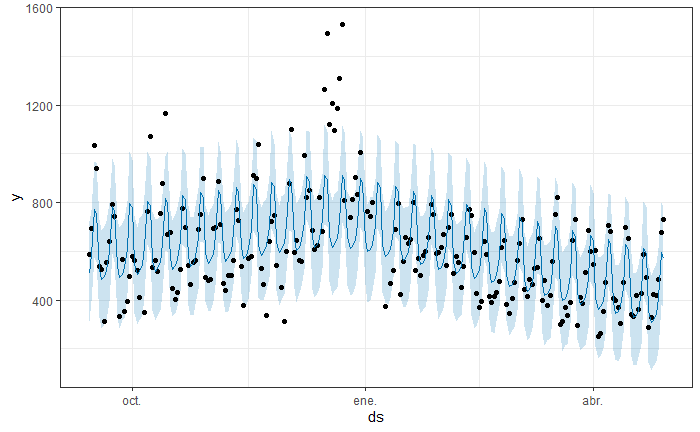

```r
plot(prophet_base,fcst=predict(prophet_base, prophet_df)) +theme_bw()
```

#### Componentes del modelo

La funcion `prophet_plot_components` nos devuelve los efectos de los componentes en nuestra variable a predecir.

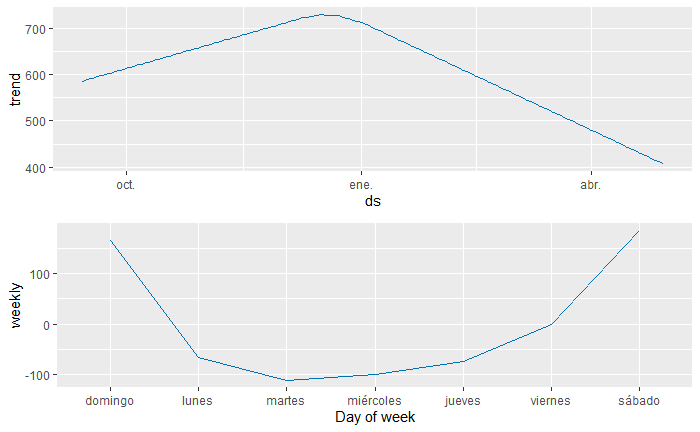

```r
prophet_plot_components(prophet_base, fcst=predict(prophet_base, prophet_df))
```

En este caso tenemos la tendencia de los visitantes y la estacionalidad semanal. Esta última parece tener bastante sentido ya que nos muestra que hay mayor cantidad de visitantes durante el fin de semana.

### Modelo con estacionalidad mensual

La función `add_seasonality` nos permite agregar nuevas estacionalidades. Las estacionalidades se modelan utilizando series de Fourier que nosotros debemos definir.

Definimos:

- **m**: modelo
- **name**: nombre de la estacionalidad
- **period**: cantidad de dias del periodo
- **fourier.order**: orden de la serie de fourier para modelar la estacionalidad

```r
# Llamamos solo al modelo
prophet_mensual=prophet()
# Agregamos la estacionalidad mensual
prophet_mensual=add_seasonality(m=prophet_mensual, name='monthly', period=365/12, fourier.order = 4)
# Le pasamos el dataset
prophet_mensual = fit.prophet(m = prophet_mensual, prophet_df)
```

```
Disabling yearly seasonality. Run prophet with yearly.seasonality=TRUE to override this.
Disabling daily seasonality. Run prophet with daily.seasonality=TRUE to override this.
```

Notemos que sigue deshabilitando la estacionalidad anual y diaria.

#### Gráfico del modelo

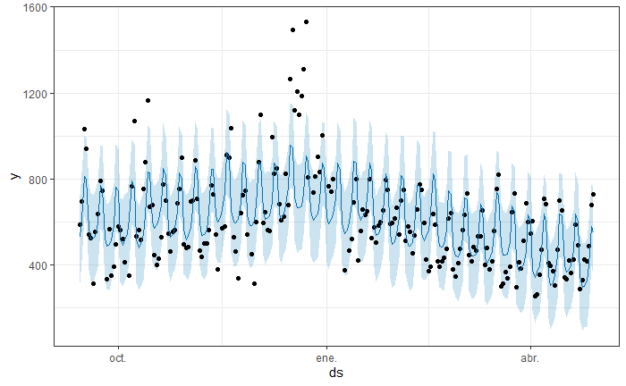

```r
plot(prophet_mensual,fcst=predict(prophet_mensual, prophet_df)) +theme_bw()
```

#### Componentes del modelo

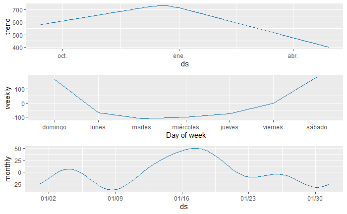

```r
prophet_plot_components(prophet_mensual, fcst=predict(prophet_mensual, prophet_df))
```

Notemos que la tendencia y estacionalidad semanal se mantiene y ahora se agrega la tendencia mensual que habíamos incorporado. Nos indica que el ciclo mensual se caracteriza por un crecimiento en la mitad de mes.

### Modelo completo

Como último paso vamos a agregar las ventas de navidad y ciertos días de promociones como eventos especiales.

#### Dataframe de eventos

Creamos el dataframe de eventos con: nombre del evento, fechas y una “ventana” para definir si el evento se estira a ciertos dias.

```r
# Navidad
christmas = data.frame(holiday= 'christmas',
  ds=ymd(c('2017-12-16','2017-12-17','2017-12-18',
                        '2017-12-19','2017-12-20','2017-12-21',
                        '2017-12-22','2017-12-23')),
  lower_window= 0,
  upper_window= 0)

# Promociones
big_sales = data.frame(
  holiday= 'big_sales',
  ds= ymd(c('2017-09-16','2017-10-08','2017-10-14',
                        '2017-11-20','2017-12-03','2017-12-30')),
  lower_window= 0,
  upper_window= 0)

holidays= bind_rows(christmas, big_sales)
glimpse(holidays)
```

```
Rows: 14
Columns: 4
$ holiday      <chr> "christmas", "christmas", "christmas", "christmas", "christ~
$ ds           <date> 2017-12-16, 2017-12-17, 2017-12-18, 2017-12-19, 2017-12-20~
$ lower_window <dbl> 0, 0, 0, 0, 0, 0, 0, 0, 0, 0, 0, 0, 0, 0
$ upper_window <dbl> 0, 0, 0, 0, 0, 0, 0, 0, 0, 0, 0, 0, 0, 0
```

```r
# Llamamos al modelo con el dataset de eventos
prophet_full=prophet(holidays = holidays)
# Agregamos la estacionalidad mensual
prophet_full=add_seasonality(prophet_full, name='monthly', period=30.5, fourier.order = 4)
# Le pasamos el dataset
prophet_full = fit.prophet(m = prophet_full, prophet_df)
```

```
Disabling yearly seasonality. Run prophet with yearly.seasonality=TRUE to override this.
Disabling daily seasonality. Run prophet with daily.seasonality=TRUE to override this.
```

Fijense que el modelo automáticamente deshabilita la estacionalidad anual y diaria.

#### Gráfico del modelo

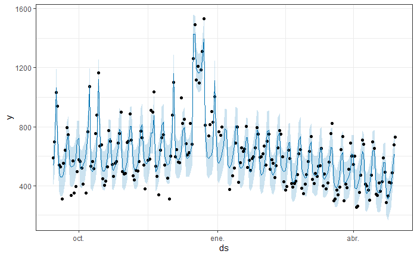

```r
plot(prophet_full,fcst=predict(prophet_full, prophet_df)) +theme_bw()
```

#### Componentes del modelo

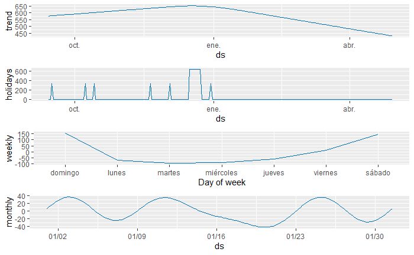

```r
prophet_plot_components(prophet_full, fcst=predict(prophet_full, prophet_df))
```

## Evaluación del modelo

La funcion `cross_validation` permite realizar pronósticos realizando un esquema de cross-validation temporal y, a partir de ellos, obtener ciertas métricas de performance.

- **horizon**: horizonte del pronóstico. Cuánto tiempo deseo predecir
- **period**: período entre fechas de análisis. Cuánto voy corriendo mi ventana
- **initial**: período inicial de entrenamiento
- **units**: unidad de tiempo utilizada

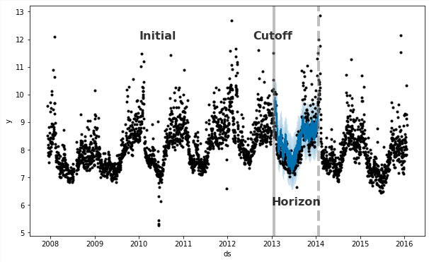

La función `cross_validation` devuelve un dataframe en el cual para cada grupo/fold de **cutoff** se obtiene para cada fecha dentro del **horizonte**: valor predicho, valor inferior del intervalo y valor superior del intervalo.

Una vez que se obtiene este dataframe se pueden obtener métricas de evaluación con la función `performance_metrics`. Definimos la proporción de datos que se utilizarán en cada ventana móvil para calcular las métricas (`rolling_window`).

El procedimiento es el siguiente:

1. Se calcula el horizonte de predicción de cada observación: ds - cutoff
2. Se ordena de menor a mayor horizonte
3. Se calculan las métricas con la cantidad de observaciones definidas por **rolling_window**.
   1. Comienza realizandolo para cada horizonte
   2. Si los datos dentro de un **horizonte** no son suficientes comienza a usar observaciones de horizontes aledaños.

Entonces, según el valor de **rolling_window** se tienen los siguientes casos:

- **rolling_window** < 0: se calculan las métricas para cada observación por separado
- **rolling_window** = 0: se calculan las métricas para cada horizonte por separado
- **rolling_window** 0 < w < 1: se calculan las métricas para cada horizonte usando el x% de las observaciones del dataframe
- **rolling_window** = 1: se calculan las métricas para todas las observaciones

Realicemos la evaluación para nuestros modelos

### Modelo básico

Usamos `cross_validation` con un período inicial de 45 días, un horizonte de 15 días y desplazaremos la predicción cada 7 días

```r
cv_base = cross_validation(prophet_base, initial = 45, period = 7, horizon = 15, units = 'days')
```

```
Making 24 forecasts with cutoffs between 2017-11-04 and 2018-04-14
```

```r
cv_base
```

| y | ds | yhat | yhat_lower | yhat_upper | cutoff |
| --- | --- | --- | --- | --- | --- |
| 710 | 2017-11-05 | 827.5072 | 658.40901 | 998.2383 | 2017-11-04 |
| 468 | 2017-11-06 | 583.8158 | 406.26199 | 764.9598 | 2017-11-04 |
| 439 | 2017-11-07 | 503.0724 | 337.46439 | 666.0940 | 2017-11-04 |
| 502 | 2017-11-08 | 491.3577 | 314.83253 | 660.8421 | 2017-11-04 |
| 500 | 2017-11-09 | 592.5476 | 425.02687 | 756.9868 | 2017-11-04 |
| 564 | 2017-11-10 | 639.8363 | 460.37489 | 802.2727 | 2017-11-04 |
| 771 | 2017-11-11 | 864.2158 | 683.63911 | 1030.1519 | 2017-11-04 |
| 727 | 2017-11-12 | 834.2786 | 661.35573 | 1010.3465 | 2017-11-04 |
| 540 | 2017-11-13 | 590.5872 | 428.95956 | 759.8428 | 2017-11-04 |
| 378 | 2017-11-14 | 509.8438 | 329.07697 | 679.1319 | 2017-11-04 |

[output cut: 328 more lines]

Obtenemos las métricas de performance

```r
performance_metrics(cv_base, rolling_window = 0.25)
```

| horizon | mse | rmse | mae | mape | mdape | smape | coverage |
| --- | --- | --- | --- | --- | --- | --- | --- |
| 4 days | 35756.11 | 189.0929 | 128.7990 | 0.2151416 | 0.1753427 | 0.2048554 | 0.8658009 |
| 5 days | 32131.70 | 179.2532 | 120.6375 | 0.2245560 | 0.1817378 | 0.2104700 | 0.8588435 |
| 6 days | 34562.39 | 185.9096 | 125.6198 | 0.2221224 | 0.1686568 | 0.2082790 | 0.8338509 |
| 7 days | 41715.64 | 204.2441 | 143.5085 | 0.2239854 | 0.1591394 | 0.2080757 | 0.7781385 |
| 8 days | 49660.13 | 222.8455 | 162.2683 | 0.2344006 | 0.1556403 | 0.2155580 | 0.7460317 |
| 9 days | 52748.42 | 229.6702 | 168.0786 | 0.2443299 | 0.1734485 | 0.2249105 | 0.7417184 |
| 10 days | 51752.04 | 227.4907 | 165.1717 | 0.2570300 | 0.2250757 | 0.2353712 | 0.7443064 |
| 11 days | 45087.46 | 212.3381 | 151.8249 | 0.2555922 | 0.2127412 | 0.2400076 | 0.7846320 |
| 12 days | 44330.81 | 210.5488 | 151.8209 | 0.2765772 | 0.2356014 | 0.2571475 | 0.7312925 |
| 13 days | 46583.51 | 215.8321 | 156.9148 | 0.2743638 | 0.2031569 | 0.2557506 | 0.7153209 |

[output cut: 2 more lines]

#### Breve explicación de la construcción de las métricas

Construimos el horizonte para nuestro set de predicciones

```r
# Construimos el horizonte
cv_base_explicacion = cv_base %>% mutate(horizon = ds-cutoff)
cv_base_explicacion[order(cv_base_explicacion$horizon),]
```

|  | y | ds | yhat | yhat_lower | yhat_upper | cutoff | horizon |
| --- | --- | --- | --- | --- | --- | --- | --- |
| 1 | 710 | 2017-11-05 | 827.5072 | 658.40901 | 998.2383 | 2017-11-04 | 1 days |
| 15 | 727 | 2017-11-12 | 793.4792 | 616.94270 | 955.8145 | 2017-11-11 | 1 days |
| 29 | 901 | 2017-11-19 | 780.8125 | 625.85002 | 944.0069 | 2017-11-18 | 1 days |
| 43 | 746 | 2017-11-26 | 806.4763 | 628.67173 | 972.3981 | 2017-11-25 | 1 days |
| 57 | 1100 | 2017-12-03 | 788.5375 | 628.65306 | 942.7306 | 2017-12-02 | 1 days |
| 72 | 851 | 2017-12-10 | 851.0757 | 661.55339 | 1028.5733 | 2017-12-09 | 1 days |
| 87 | 1494 | 2017-12-17 | 887.0683 | 715.45347 | 1053.8639 | 2017-12-16 | 1 days |
| 100 | 809 | 2017-12-24 | 1203.2751 | 1001.61463 | 1403.6159 | 2017-12-23 | 1 days |
| 129 | 798 | 2018-01-14 | 1044.2824 | 783.04949 | 1297.7453 | 2018-01-13 | 1 days |
| 144 | 523 | 2018-01-21 | 1005.2265 | 739.57059 | 1243.6876 | 2018-01-20 | 1 days |

[output cut: 328 more lines]

Observemos cuantas observaciones tenemos por horizonte

```r
cv_base_explicacion %>% group_by(horizon) %>% count()
```

| horizon | n |
| --- | --- |
| 1 days | 22 |
| 2 days | 21 |
| 3 days | 23 |
| 4 days | 22 |
| 5 days | 24 |
| 6 days | 23 |
| 7 days | 23 |
| 8 days | 22 |
| 9 days | 21 |
| 10 days | 23 |

[output cut: 5 more lines]

La ventana se define de la siguiente manera:

```r
# El código se adaptó del código fuente de la librería
n_observaciones_ventana = function(rolling_window, cv_df){
  w <- as.integer(rolling_window * nrow(cv_df))
    if (w >= 0) {
      w <- max(w, 1)
      w <- min(w, nrow(cv_df))
    }
  return(w)
}
```

**Rolling window < 0**

```r
rolling_window = -1
# Cantidad de observaciones
n_observaciones_ventana(rolling_window, cv_base)
```

```
[1] -338
```

```r
# Set de metricas
performance_metrics(cv_base, rolling_window=rolling_window)
```

| horizon | mse | rmse | mae | mape | mdape | smape | coverage |
| --- | --- | --- | --- | --- | --- | --- | --- |
| 1 days | 1.380794e+04 | 117.50718626 | 117.50718626 | 1.655031e-01 | 1.655031e-01 | 1.528542e-01 | TRUE |
| 1 days | 4.419482e+03 | 66.47918826 | 66.47918826 | 9.144318e-02 | 9.144318e-02 | 8.744505e-02 | TRUE |
| 1 days | 1.444504e+04 | 120.18750797 | 120.18750797 | 1.333935e-01 | 1.333935e-01 | 1.429262e-01 | TRUE |
| 1 days | 3.657383e+03 | 60.47630201 | 60.47630201 | 8.106743e-02 | 8.106743e-02 | 7.790947e-02 | TRUE |
| 1 days | 9.700888e+04 | 311.46248991 | 311.46248991 | 2.831477e-01 | 2.831477e-01 | 3.298452e-01 | FALSE |
| 1 days | 5.727394e-03 | 0.07567955 | 0.07567955 | 8.893014e-05 | 8.893014e-05 | 8.892618e-05 | TRUE |
| 1 days | 3.683661e+05 | 606.93173754 | 606.93173754 | 4.062461e-01 | 4.062461e-01 | 5.097978e-01 | FALSE |
| 1 days | 1.554529e+05 | 394.27512382 | 394.27512382 | 4.873611e-01 | 4.873611e-01 | 3.918700e-01 | FALSE |
| 1 days | 6.065502e+04 | 246.28240245 | 246.28240245 | 3.086246e-01 | 3.086246e-01 | 2.673666e-01 | TRUE |
| 1 days | 2.325424e+05 | 482.22649212 | 482.22649212 | 9.220392e-01 | 9.220392e-01 | 6.310930e-01 | FALSE |

[output cut: 328 more lines]

**Rolling window = 0**

```r
rolling_window = 0
# Cantidad de observaciones
n_observaciones_ventana(rolling_window, cv_base)
```

```
[1] 1
```

```r
# Set de metricas
performance_metrics(cv_base, rolling_window=rolling_window)
```

| horizon | mse | rmse | mae | mape | mdape | smape | coverage |
| --- | --- | --- | --- | --- | --- | --- | --- |
| 1 days | 50848.89 | 225.4970 | 165.02433 | 0.2109115 | 0.1504622 | 0.1960674 | 0.8181818 |
| 2 days | 40329.67 | 200.8225 | 144.57249 | 0.2553091 | 0.2474697 | 0.2413679 | 0.8095238 |
| 3 days | 36334.63 | 190.6164 | 128.43001 | 0.2474832 | 0.2058690 | 0.2291717 | 0.8695652 |
| 4 days | 18436.99 | 135.7829 | 84.48951 | 0.1464491 | 0.1207828 | 0.1517711 | 0.9545455 |
| 5 days | 35533.64 | 188.5037 | 131.34614 | 0.2549614 | 0.1704108 | 0.2270438 | 0.7916667 |
| 6 days | 47817.38 | 218.6719 | 157.15369 | 0.2436991 | 0.1683876 | 0.2291237 | 0.7391304 |
| 7 days | 56234.29 | 237.1377 | 178.47904 | 0.2191448 | 0.1515805 | 0.2015073 | 0.6956522 |
| 8 days | 54987.47 | 234.4941 | 173.15678 | 0.2256752 | 0.1515588 | 0.2077119 | 0.7727273 |
| 9 days | 50811.47 | 225.4140 | 160.73197 | 0.2919973 | 0.3179001 | 0.2649488 | 0.7619048 |
| 10 days | 46008.19 | 214.4952 | 151.17320 | 0.2847440 | 0.2311170 | 0.2613247 | 0.7391304 |

[output cut: 5 more lines]

**Rolling window = 0.25**

```r
rolling_window = 0.25
# Cantidad de observaciones
n_observaciones_ventana(rolling_window, cv_base)
```

```
[1] 84
```

```r
# Set de metricas
performance_metrics(cv_base, rolling_window=rolling_window)
```

| horizon | mse | rmse | mae | mape | mdape | smape | coverage |
| --- | --- | --- | --- | --- | --- | --- | --- |
| 4 days | 35756.11 | 189.0929 | 128.7990 | 0.2151416 | 0.1753427 | 0.2048554 | 0.8658009 |
| 5 days | 32131.70 | 179.2532 | 120.6375 | 0.2245560 | 0.1817378 | 0.2104700 | 0.8588435 |
| 6 days | 34562.39 | 185.9096 | 125.6198 | 0.2221224 | 0.1686568 | 0.2082790 | 0.8338509 |
| 7 days | 41715.64 | 204.2441 | 143.5085 | 0.2239854 | 0.1591394 | 0.2080757 | 0.7781385 |
| 8 days | 49660.13 | 222.8455 | 162.2683 | 0.2344006 | 0.1556403 | 0.2155580 | 0.7460317 |
| 9 days | 52748.42 | 229.6702 | 168.0786 | 0.2443299 | 0.1734485 | 0.2249105 | 0.7417184 |
| 10 days | 51752.04 | 227.4907 | 165.1717 | 0.2570300 | 0.2250757 | 0.2353712 | 0.7443064 |
| 11 days | 45087.46 | 212.3381 | 151.8249 | 0.2555922 | 0.2127412 | 0.2400076 | 0.7846320 |
| 12 days | 44330.81 | 210.5488 | 151.8209 | 0.2765772 | 0.2356014 | 0.2571475 | 0.7312925 |
| 13 days | 46583.51 | 215.8321 | 156.9148 | 0.2743638 | 0.2031569 | 0.2557506 | 0.7153209 |

[output cut: 2 more lines]

**Rolling window = 1**

```r
rolling_window = 1
# Cantidad de observaciones
n_observaciones_ventana(rolling_window, cv_base)
```

```
[1] 338
```

```r
# Set de metricas
performance_metrics(cv_base, rolling_window=rolling_window)
```

| horizon | mse | rmse | mae | mape | mdape | smape | coverage |
| --- | --- | --- | --- | --- | --- | --- | --- |
| 15 days | 48155.24 | 219.443 | 156.2411 | 0.2472023 | 0.1842551 | 0.2289996 | 0.760355 |